# Reproducible Research: Peer Assessment 1

## Loading and preprocessing the data

```r
fileUrl <- "https://d396qusza40orc.cloudfront.net/repdata%2Fdata%2Factivity.zip"
download.file(fileUrl, destfile = "./activity.zip")
unzip("./activity.zip")
d <- read.csv("activity.csv", na.strings = "NA")
names(d)
```

```
## [1] "steps"    "date"     "interval"
```

```r
head(d)
```

```
##   steps       date interval
## 1    NA 2012-10-01        0
## 2    NA 2012-10-01        5
## 3    NA 2012-10-01       10
## 4    NA 2012-10-01       15
## 5    NA 2012-10-01       20
## 6    NA 2012-10-01       25
```

```r
# convert date variable to Date type
d$date <- as.Date(d$date, "%Y-%m-%d")
```

## What is mean total number of steps taken per day?

1. Calculate the total number of steps taken per day.

```r
d_omit_na <- na.omit(d)
steps_per_day <- with(d_omit_na, aggregate(steps, by = list(date), sum))
```

2. Make a histogram of the total number of steps taken each day.

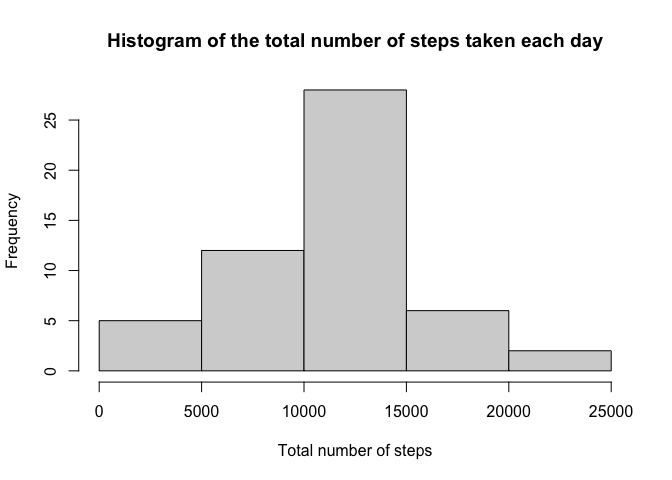

```r
hist(steps_per_day$x, xlab = "Total number of steps", main = "Histogram of the total number of steps taken each day")
```

3. Calculate and report the mean and median of the total number of steps taken per day

```r
mean(steps_per_day$x)
```

```
## [1] 10766.19
```

```r
median(steps_per_day$x)
```

```
## [1] 10765
```

## What is the average daily activity pattern?

1. Make a time series plot (i.e. type = “l”) of the 5-minute interval (x-axis) and the average number of steps taken, averaged across all days (y-axis)

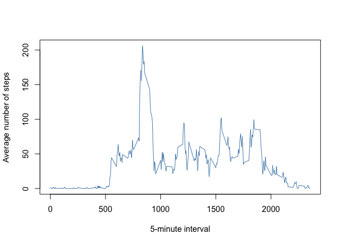

```r
steps_avg <- aggregate(d$steps, by = list(d$interval), mean, na.rm = T)
plot(steps_avg$Group.1, steps_avg$x, type = "l", col = "steelblue", xlab = "5-minute interval", ylab = "Average number of steps")
```

2. Which 5-minute interval, on average across all the days in the dataset, contains the maximum number of steps?

```r
steps_max <- which.max(steps_avg$x)
steps_avg$Group.1[steps_max]
```

```
## [1] 835
```

## Imputing missing values

1. Calculate and report the total number of missing values in the dataset (i.e. the total number of rows with NAs)

```r
sum(is.na(d$steps))
```

```
## [1] 2304
```

2. Devise a strategy for filling in all of the missing values in the dataset. The strategy does not need to be sophisticated. For example, you could use the mean/median for that day, or the mean for that 5-minute interval, etc.

```r
# use the mean for that 5-minute interval to fill the missing value
fill_missing_value <- function(interval){
     steps_avg[which(steps_avg[1] == interval), 2]
}
```

3. Create a new dataset that is equal to the original dataset but with the missing data filled in.

```r
d_filled <- within(d, steps[is.na(steps)] <- fill_missing_value(interval))
```

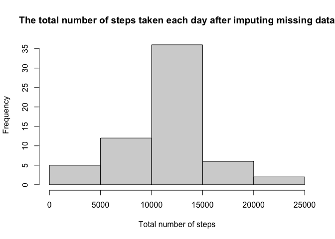

```r
steps_filled_per_day <- with(d_filled, aggregate(steps, by = list(date), sum))
hist(steps_filled_per_day$x, xlab = "Total number of steps", main = "The total number of steps taken each day after imputing missing data")
```

```r
mean <- mean(steps_filled_per_day$x)
median <- median(steps_filled_per_day$x)
```

## Are there differences in activity patterns between weekdays and weekends?

1. Create a new factor variable in the dataset with two levels – “weekday” and “weekend” indicating whether a given date is a weekday or weekend day.

```r
d_filled$weekend <- weekdays(d_filled$date) %in% c("Saturday", "Sunday")
d_filled$weekend <- factor(d_filled$weekend, c(FALSE, TRUE), labels = c("weekday", "weekend"))
```

2. Make a panel plot containing a time series plot (i.e. type = “l”) of the 5-minute interval (x-axis) and the average number of steps taken, averaged across all weekday days or weekend days (y-axis).

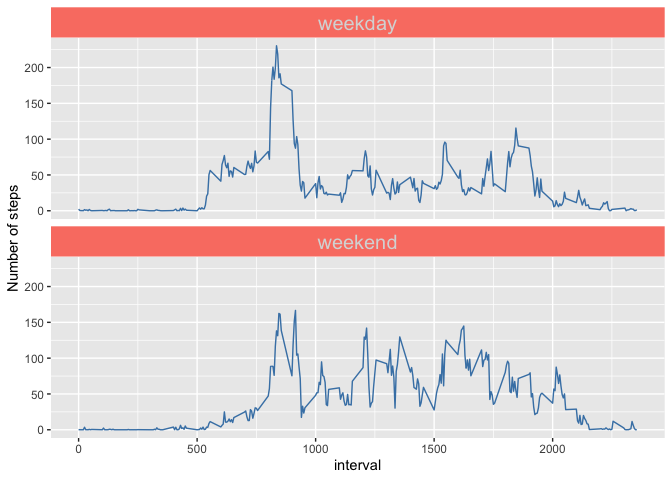

```r
steps_filled_avg <- with(d_filled, aggregate(steps, by = list(interval, weekend), mean))
names(steps_filled_avg) <- c("interval", "weekend", "avg")

library(ggplot2)
g<- ggplot(data = steps_filled_avg, aes(x = interval, y = avg, fill = weekend))
g + geom_line(color = "steelblue") +
        facet_wrap(weekend~., nrow = 2) +
        ylab("Number of steps") +
        theme(strip.background = element_rect(fill="salmon"),
              strip.text.x = element_text(size = 15, colour = "gray85"))
```